# Part II - Ford GoBike Data Set Analysis

## by Shanshan Chu

## Investigation Overview

> For the given data set which contains trip information for a bike-sharing system, my goal to know more time and location related information for the collected trips, as well as the user information. Such data exploration of this data set will give us some insights about the bike-sharing market in SF area.

### Key Findings

> User background: The most users for Ford GoBike are around 20 to 40 years old, male. Most of the users are subscribers. Using time: The most bike using time is on weekdays during rush hours for work. Usage duration: despite those extremely long and short usage, most users use the bike less than 40 minutes. Gender and user type does not have a large impact on the duration time.

## Dataset Overview

> The data set that I analyzed includes information about individual rides made in a bike-sharing system (Ford GoBike) covering the greater San Francisco Bay area. The data includes information about each trip for Ford GoBike (e.g. the start and end time, the start and ending station) and user information (e.g. user's subscription status and ages).

## User background

> For this part, I will present my findings about user background. I will show the users' age distribution, genders, and subscribe status.

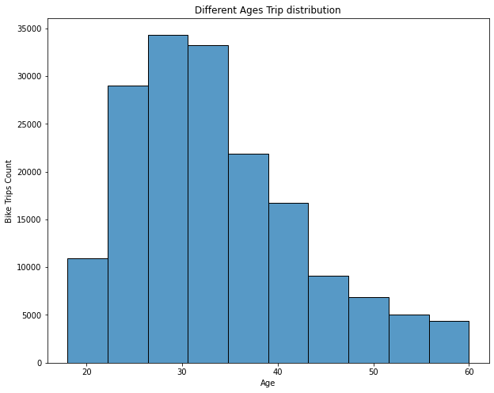

```python
# Set color
color = sb.color_palette('colorblind')[0]

plt.figure(figsize=(10,8))
sb.histplot(x = 'member_age', data = df,bins=10)
plt.title('Different Ages Trip distribution')
plt.xlabel('Age')
plt.ylabel('Bike Trips Count');
```

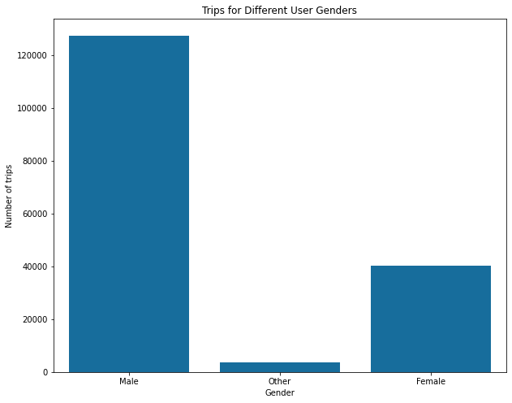

```python
plt.figure(figsize = [10, 8])
sb.countplot(data=df, x='member_gender',color=color);
plt.title('Trips for Different User Genders')
plt.xlabel('Gender');
plt.ylabel('Number of trips');
```

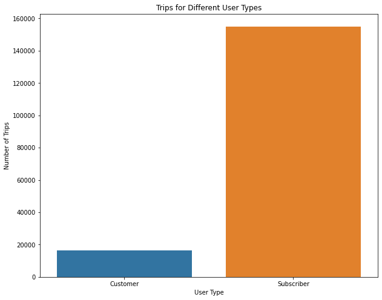

```python
plt.figure(figsize=(10,8))
sb.countplot(data=df, x='user_type')
plt.title('Trips for Different User Types')
plt.ylabel('Number of Trips')
plt.xlabel('User Type');
```

> See from the results, I found that the most users for Ford GoBike are around 20 to 40 years old, male. Most of the users are subscribers.

## Using time

> For this part, I will show the users' start/end time in the scale of both 24 hours and 7 days.

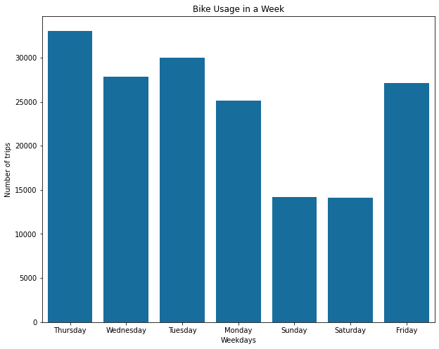

```python
plt.figure(figsize=(10,8))
sb.countplot(x = 'weekday', data = df, color=color)
plt.title('Bike Usage in a Week')
plt.xlabel('Weekdays')
plt.ylabel('Number of trips');
```

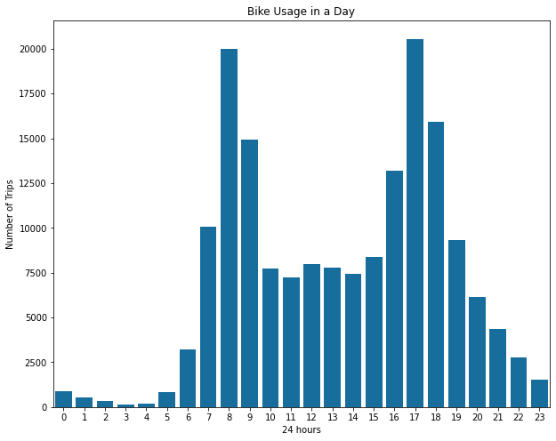

```python
plt.figure(figsize=(10,8))
sb.countplot(data = df, x='start_time_hour', color=color)
plt.title("Bike Usage in a Day")
plt.xlabel("24 hours")
plt.ylabel("Number of Trips")
plt.show();
```

> See from the result, I found that the most bike using time is on weekdays during rush hours for work.

## Usage duration

> For this part, I will use the plot of the duration for different gender and user types as example, to demonstrate the point that gender and user type does not have a large impact on the duration time.

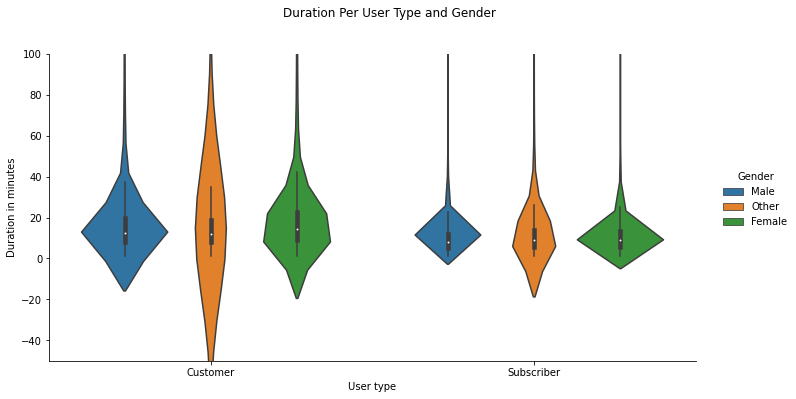

```python
plt.figure(figsize=(10,8))
graph = sb.catplot(data=df, x='user_type', y="duration_minute", hue="member_gender", kind="violin", aspect=2);

plt.ylim([-50, 100])
graph.set_axis_labels("User type", "Duration in minutes")
graph._legend.set_title('Gender')
graph.fig.suptitle('Duration Per User Type and Gender', y=1.1);
```

> See from the result, I found that despite those extremely long and short usage, most users use the bike less than 40 minutes. Gender and user type does not have a large impact on the duration time.